# 6_1_BenchmarkModels_FittedValues_Forecasts

## Forecasts

To produce forecasts in the `fable` library we use the `forecast()` function on the fitted model. We specify an argument: `h` and the number of time steps we wish to forecast.

```r
# produce forecasts for 8 timesteps
forecasts <- fit %>% forecast(h = 8)
forecasts
```

```
# A fable: 8 x 4 [1Q]
# Key:     .model [1]
  .model Quarter       Bricks .mean
  <chr>    <qtr>       <dist> <dbl>
1 mean   2005 Q1 N(451, 4022)  451.
2 mean   2005 Q2 N(451, 4022)  451.
3 mean   2005 Q3 N(451, 4022)  451.
4 mean   2005 Q4 N(451, 4022)  451.
5 mean   2006 Q1 N(451, 4022)  451.
6 mean   2006 Q2 N(451, 4022)  451.
7 mean   2006 Q3 N(451, 4022)  451.
8 mean   2006 Q4 N(451, 4022)  451.
```

The output is a so called **fable** (forecast table). In fact, the package itself is called `fable`. There is a column that contains the forecast distribution. We will see how to handle these objects later in the subject. The column **.mean** is the point forecast, the mean of the forecast distribution. Remember from **session 1** that **point forecasts are usually the mean of the forecast distribution** (sometimes we may want to choose the median over the mean).

**Important**: to depict the forecasts along with the time series use **autoplot on the fable object (in our case the variable forecasts) and then specify the original variable within autoplot (in this case Bricks)**. This will result in the forecasts being depicted along the original time series:

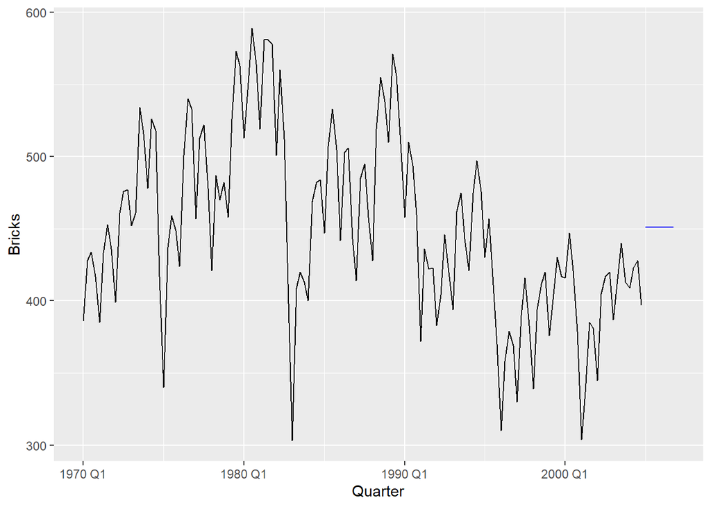

```r
# TO depict the forecasts and the original series use autoplot() with the
forecasts %>%

# Depicts the original time series and the forecasts
autoplot(bricks, level = FALSE)
```

If you now wisht to add the fitted values, you may use `geom_line()` to add another layer to the graph:

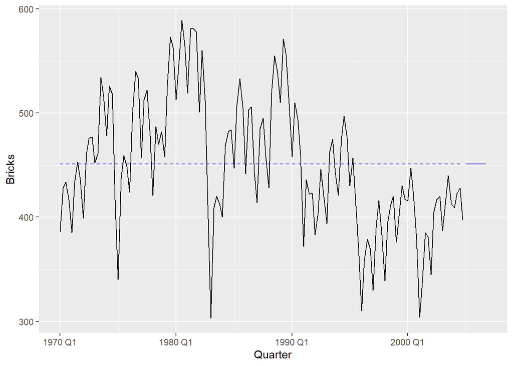

```r
# TO depict the forecasts and the original series use autoplot() with the
forecasts %>%

# Depicts the original time series and the forecasts
autoplot(bricks, level = FALSE) +

# Overlays the fitted values
geom_line(data = fitted_vals, aes(y = .fitted), colour = "blue", linetype = "dashed")
```

## Number of parameters

Using the function `tidy()` on a fitted model, we can get the number of parameters of the model

```r
tidy(fit)
```

```
# A tibble: 1 × 6
  .model term  estimate std.error statistic   p.value
  <chr>  <chr>    <dbl>     <dbl>     <dbl>     <dbl>
1 mean   mean      451.      5.34      84.4 2.58e-121
```

In this case there is **only one parameter**, the mean of the sample.